# El ejercicio físico y el desempeño académico

## Librerias

```r
library(readr)
library(dplyr)
library(ggplot2)
```

## Base de datos

Se trabaja con la base de datos DF1

## Limpieza de datos

### Cambio de nombre de nuestras variables en estudio

Tenemos en cuenta que no deben haber variables con nombres con tildes o nombres compuestos separados en blancos y en la encuesta con nuestros datos hemos restringido las respuestas para evitar respuestas de algún otro tipo de carácter.

### Re-definiendo las variables útiles

Se elijen las variables útiles para el estudio

```
##  [1] "Marca"      "Correo"     "Nombre"     "Ciclo"      "Edad"
##  [6] "Genero"     "Carrera"    "Peso"       "Estatura"   "Credito"
## [11] "Hestudio"   "Promediop"  "Ejercicio"  "Hejercicio" "TipoE"
## [16] "SensacionE"
```

```
##  [1] "Ciclo"      "Edad"       "Genero"     "Carrera"    "Peso"
##  [6] "Estatura"   "Credito"    "Hestudio"   "Promediop"  "Ejercicio"
## [11] "Hejercicio" "TipoE"      "SensacionE"
```

```
## [1] 13
```

## Relevancia

### OBJETIVO GENERAL

Evaluar los resultados del estudio y la relación que tiene el desempeño académico con respecto a la actividad física, haciendo un análisis de distintas variables para finalmente recomendar a los alumnos de UTEC como es que llevar una vida con actividades físicas podría ayudar a mejorar su rendimiento académico.

## RELEVANCIA

La relevancia de estudiar el tema es para hacer el estudio de la relación que existe entre el desempeño académico con respecto a la actividad física, analizando variables como el promedio ponderado,tipo de actividad física, nivel de sensación entre otros. Finalmente poder brindar una información a la comunidad de UTEC sobre las beneficios o consecuencias de las actividades físicas con respecto a un mejor rendimiento académico.

## Descripción de las variables

-Carrera: Esta variable ayudara al estudio para determinar que carrera universitaria muestra un mejor desempeño académico con respecto a su actividad física. La carrera con mejores resultados, será usada como referencia para proponer mejoras en el desempeño académico en las demás carreras.

-Peso: Esta variable nos dará un estudio de relación de la actividad física con respecto a su peso, es decir comprobar si el peso ideal determinaría más horas de actividad física y finalmente lo relacionaremos con el desempeño académico.

-Promedio ponderado: Esta variable ayudará a determinar el desempeño académico en el ciclo 2021-2 el cual será relacionado con la actividad física, para que finalmente aportara en la conclusión si ambas variables tiene proporcionalidad.

-Hestudio: Esta variable ayudará a determinar el tiempo que los estudiantes estudian y ver diferencias de los tiempos entre los que entrenan y no, para ver la relación con el desempeño académico.

-Hejercicio: Medir el rendimiento académico a base del tiempo de ejercicio para verificar el vínculo entre el rendimiento académico con la cantidad de horas en que el estudiante realiza actividades físicas.

-TipoE: Esta variable nos determinará que tipo de actividad física realizan los estudiantes.

-SensaciónE: El nivel de sensación con respecto a la actividad física, esto aportará al estudio a determinar como los estudiantes se sienten en energía, después de realizar actividad física y relacionar ello, con el desempeño académico.

## Descriptores numéricos

### Posición

-Carrera: La carrera que más está presente es ing industrial ya que es la moda con 49 estudiantes de una muestra de 200 estudiantes.

-Estatura: La media del espacio muestral es 1.689m, es decir el promedio de la muestra de estudiantes son de esta estatura, donde el mínimo fue 1.45m y el máximo 1.89m, por lo tanto el rango de la muestra es 0.44m, y su mediana es 1.68m.

-Créditos: La media del espacio muestral es 16.37,es decir durante el ciclo de estudio el promedio de créditos que llevaron los alumnos fue de este valor y la mediana es 17 de un rango de muestra de 24.

-Horas de estudio: La media del espacio muestral es 18.88 por lo tanto los estudiantes invierten aproximadamente 3 horas al día en estudiar, el rango de la muestra es 83, donde el mínimo fue 1, el máximo 84 horas y mediana 15.

-Promedio de notas: La media es de 15.29,la mediana del espacio muestral es 15.40, es decir la mitad de las notas promedio de los estudiantes tienen 15.40 o menos de 15.40 y la otra mitad 15.40 o más de 15.40, dentro de un rango de una muestra de 9.9, donde el mínimo fue 10 y el máximo 19.90.

-Actividad física (si o no): 166 si y 34 no, donde la mayoría de estudiantes realizan actividades físicas.

-Horas de actividad física: La mediana es 6, la media del espacio muestral es 7.533, por lo tanto los alumnos muestran una constante actividad física durante la semana, el rango de la muestra es 29, donde el mínimo fue 1 y el máximo 30, sin embargo hay estudiantes que no realizan actividad física.

-Sensación (Después de ejercitarse): La mediana del espacio muestral es 8, el rango de la muestra es 7, donde el mínimo fue 3 y el máximo 10.

### Dispersión

-Edad: El rango de 13, mínimo 16 y máximo 29, su IQR es 4, su desviación estándar es 2.41 y su coeficiente de variación es 0.12.

-Estatura: Su mínimo fue 1.45m y el máximo 1.89m, por lo tanto el rango de la muestra es 0.44m, su IQR es de 0.13, es decir que los valores no están muy dispersos porque el valor es muy pequeño a comparación del IQR de otras variables,además que su desviación estándar es de 0.093 lo cual corrobora que los valores no están muy dispersos alrededor de la media, su coeficiente de variación es 0.055.

-Crédito: Su rango de muestra de 24, donde el mínimo fue 4 y el máximo 28, su IQR es de 5.25, su coeficiente de variación es 0.26 y su desviación estándar es de 4.28.

-Horas de estudio: El rango de la muestra es 83, donde el mínimo fue 1 y el máximo 84, su IQR es de 13.25, es decir que los valores están dispersos porque presentan un IQR mucho mayor a comparación de las otras variables además su desviación estándar es de 14.38 lo cual corrobora los valores dispersos de esta variable y su coeficiente de variación es de 0.76.

-Promedio: Tiene un rango de 9.9 dónde su mínimo es 10 y el máximo 19.90, quantil 1 es 14, y quantil 3 es 17, su IQR es 3 y su coeficiente de variación 0.13.

-Horas de ejercicio: El rango de la muestra es 29, donde el mínimo fue 1, sin embargo hay estudiantes que no realizan actividad física y el máximo 30, su IQR es 6 es decir que los valores de esta variable no están relativamente dispersos porque presenta un valor promedio a comparación con las otras variables además su desviación estándar 5.13 corrobora este análisis y el coeficiente de variación es 0.68.

-Sensación: Su rango es 7 dónde el mínimo es 3 y su máximo 10,no presentamos una sensación mínima de 0, nos da una información que al entrenar los estudiantes no se logran sentir sin energía, al contrario en su sensación repercute positivamente, su IQR es 3, dónde hay quantil 1 es 6 y quantil 3 es 9, su desviación estándar es 1.84 y su coeficiente de variación es de 0.24.

## Descriptores gráficos

### Mosaico

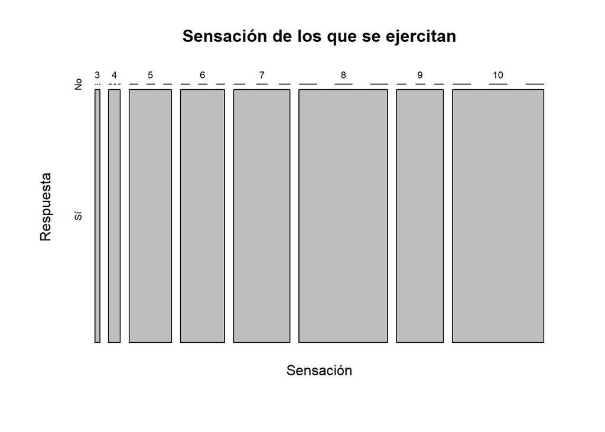

### Diagrama de caja

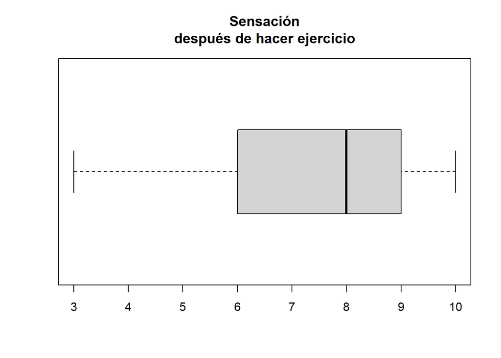

Análisis: Este es otra forma de representar el nivel de satisfacción de los estudiantes después de realizar ejercicio, se puede concluir que los estudiantes después de realizar ejercicio, un 25% de los estudiantes se sienten con una sensación menos de 6 y el 75% de las personas se sienten con más de 6. Esto gracias a nuestro quantil 1, todos los que entrenan en su mayoría, si tienen un impacto positivo en sus energías, vemos que nadie se siente sin energía durante su semana al entrenar, por ultimo, un 25 % se siente con 9 o más 9 en la semana, estudiantes que logran tener una satisfacción casi máxima.

### Diagrama de dispersión

```r
cov(DFN$Credito, DFN$Hejercicio,use="complete.obs")
```

```
## [1] -1.896728
```

```r
cor(DFN$Credito, DFN$Hejercicio, use="complete.obs")
```

```
## [1] -0.08754667
```

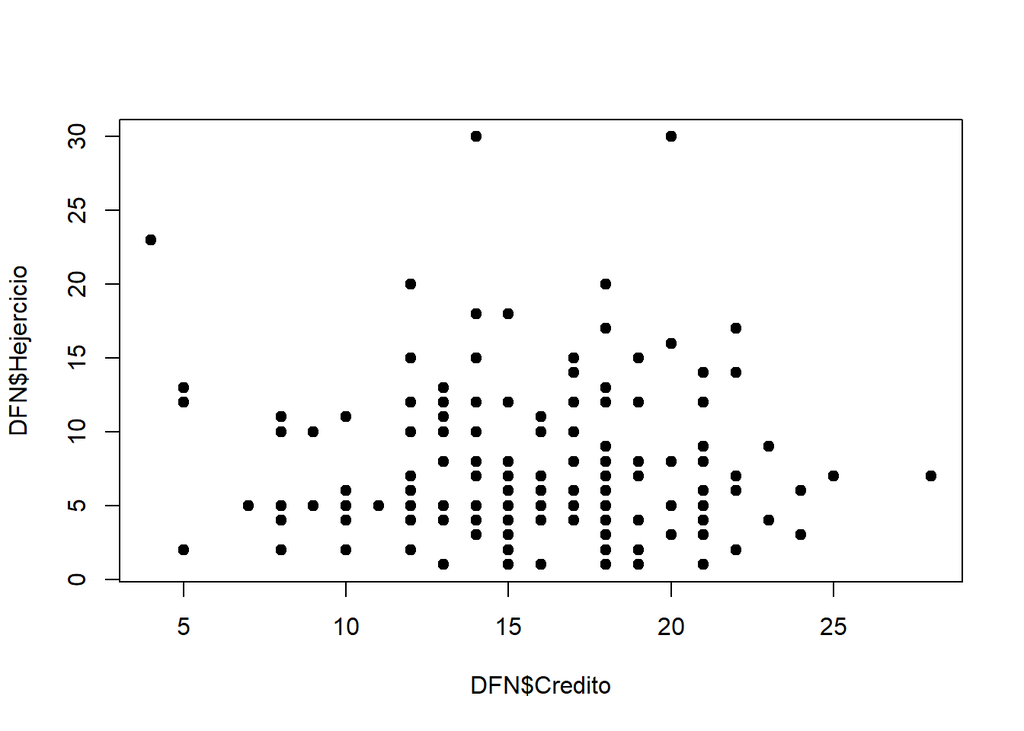

### Diagrama de caja

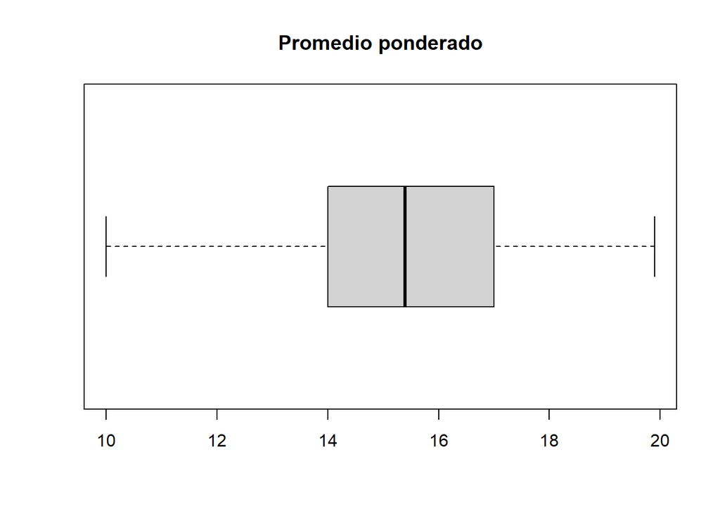

Análisis: Vemos claramente que nuestra muestra, un 25% de los estudiantes tienen menos de 14 en su promedio ponderado y el 75% de las personas con un promedio ponderado de 14 a más de 14. Esto gracias a nuestro quantil 1, por lo que vemos una gran cantidad de aprobados, independiente de cuantos créditos lleven y porque el 83% de nuestros estudiantes entrenan, se obtiene un impacto positivo en el desempeño de los estudiantes.

### Histogramas

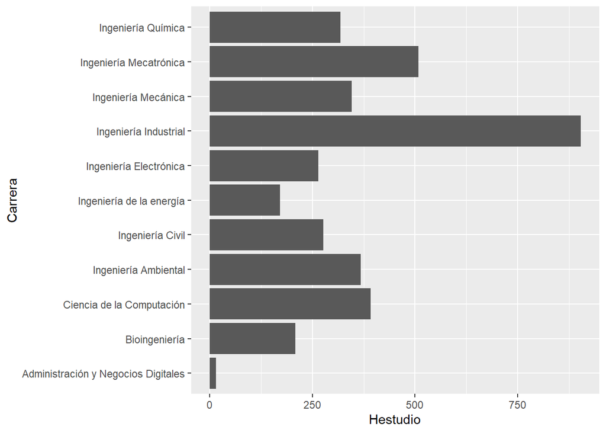

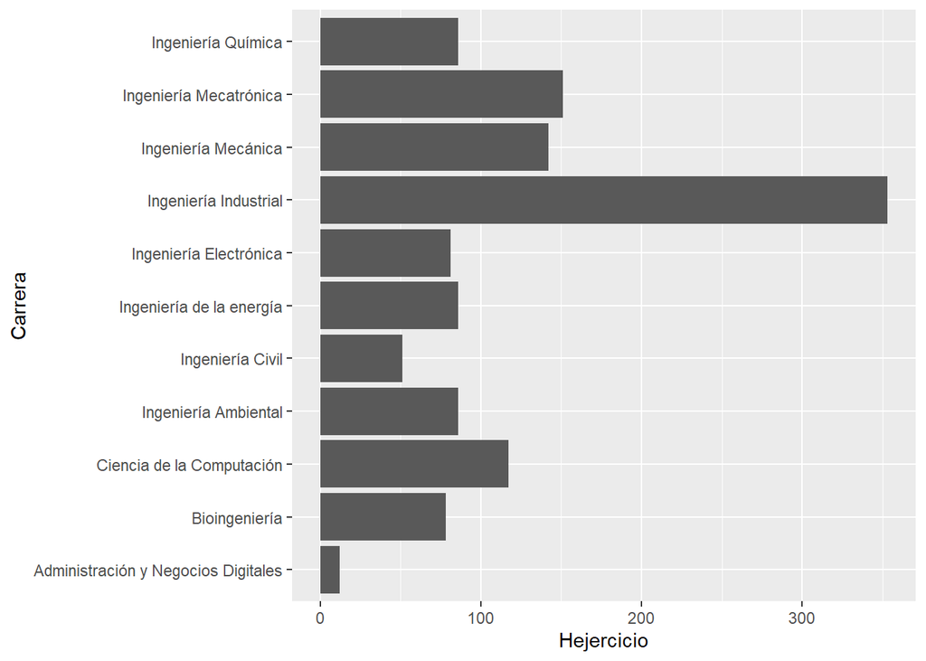

```r
l <- ggplot(data = sub) + geom_bar(mapping = aes(x = Carrera, y = Hejercicio), stat = "identity")
l + coord_flip()
```

Análisis: En estos 2 gráfico vemos que los estudiantes que más estudian son los de ingeniería industrial,por otro lado, ellos mismos son los que más entrenan, por lo que ellos muestran un balance de sus horas de estudio y entrenamiento, nos servirá como referencia estos estudiantes para aportar a los demás, son 49 estudiantes que pertenecen a este carrera, representa nuestra moda en nuestro estudio.

## Variables aleatorias

Para identificar las variables aleatorias, procedemos a realizar los histogramas de algunas de las variables que forman parte del estudio, después se podrá modelar y aproximar cada una de ellas con un modelo, hallando sus parámetros *aproximados*, gracias a nuestra muestra tomada de la población de estudiantes de UTEC.

### Distribución de la variable estatura

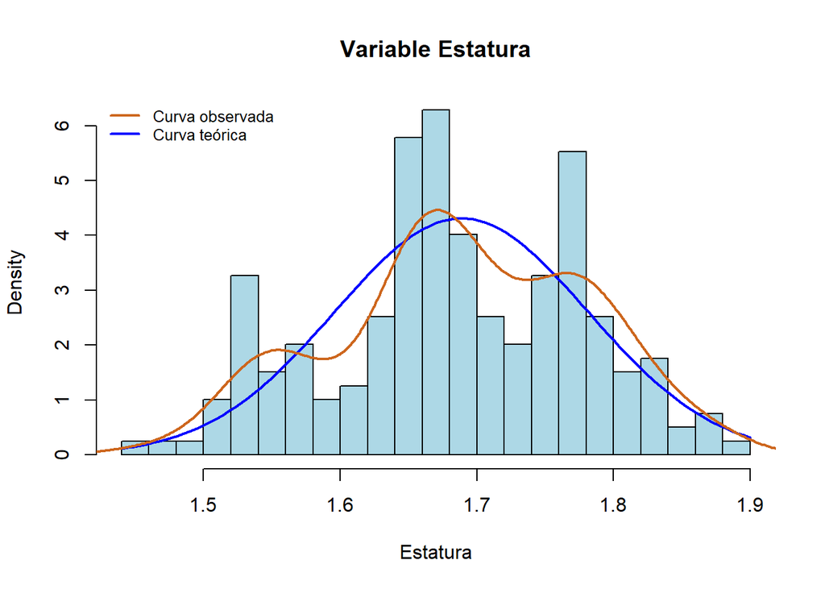

```
## [1] 1.688593
```

```
## [1] 0.09254554
```

Como se puede observar esta distribución de datos tiene una forma bastante *similar* a la de una campana de Gauss, es decir, tiene una distribución muy similar a la normal.Además, es una distribución multimodal, puesto que la gráfica presenta 3 picos. Logramos justificar la elección de la distribución normal, porque hay simetría en la distribución de los datos, ello se demuestra con los valores de moda, mediana y media que son *parecidos*.

mediana=1.680, media=1.689, moda=1.65 *Estatura ~ Nor(1.69, 0.09)

### Distribución de la variable promedio

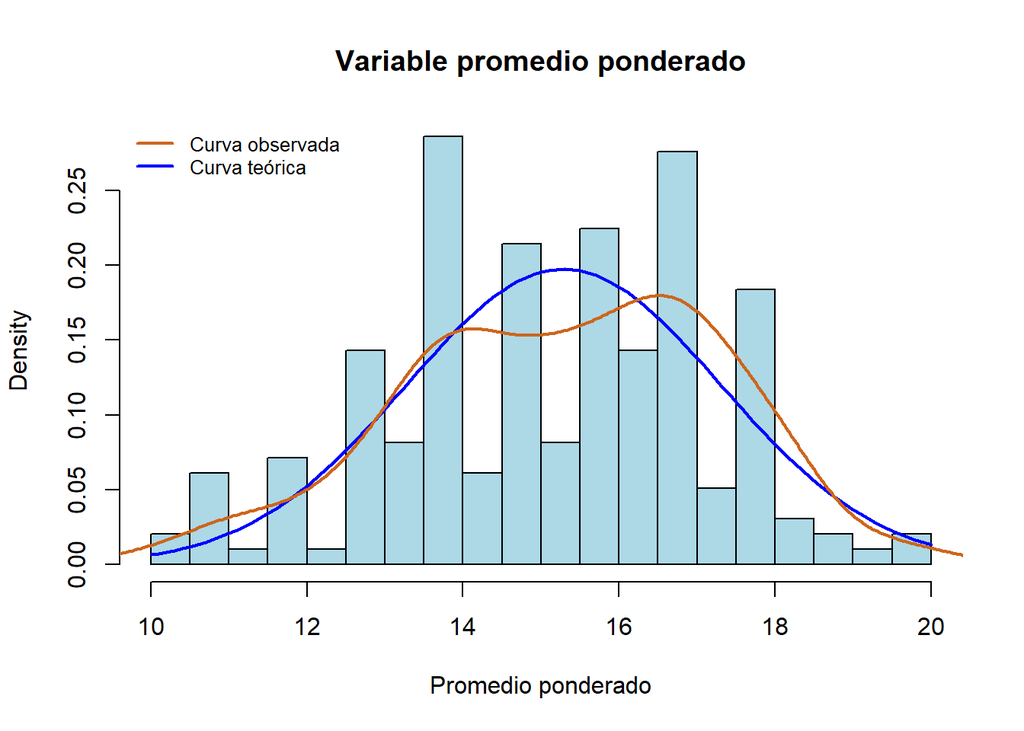

```
## [1] 15.28903
```

```
## [1] 2.022453
```

Como se puede observar esta distribución de datos tiene una forma bastante *similar* a la de una campana de Gauss, es decir, tiene una distribución muy similar a la normal. Además, es una distribución bimodal, puesto que la gráfica presenta 2 picos. Logramos justificar la elección de la distribución normal, porque hay simetría en la distribución de los datos, ello se demuestra con los valores de moda, mediana y media que son *parecidos*.

mediana=15.40 , media=15.29, moda=17

- Promediop ~ Nor(15.29, 2.02)

### Distribución de la variable peso

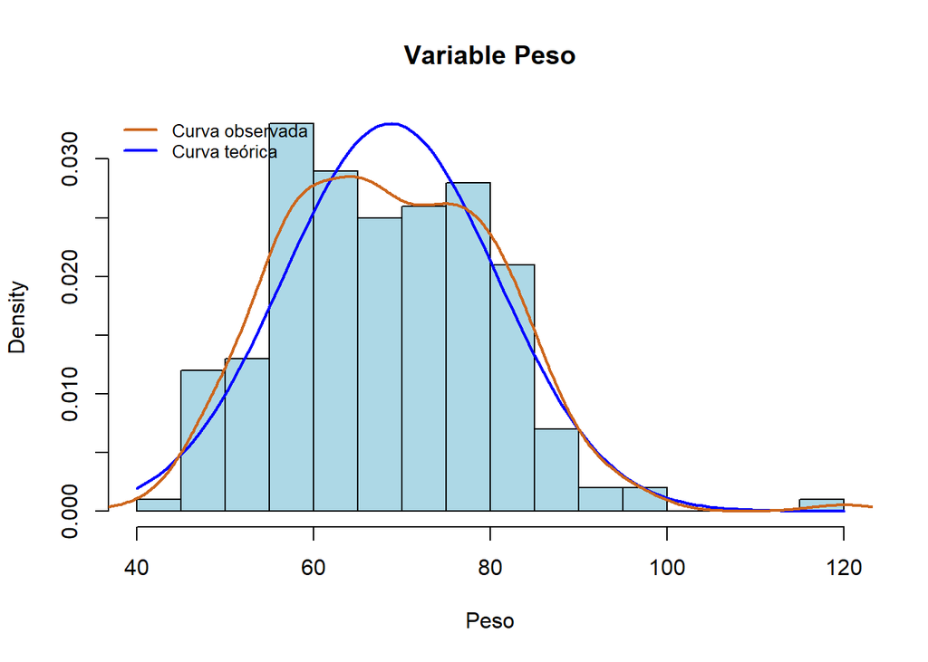

Como se puede observar esta distribución de datos tiene una forma bastante *similar* a la de una distribución muy similar a la normal. Además, es una distribución unimodal, puesto que la gráfica presenta 1 pico mas grande con respecto a los demás. Logramos justificar la elección de la distribución normal, porque hay simetría en la distribución de los datos, ademas la naturaleza de la variable es continua, a pesar que este discretizada, ello se demuestra con los valores de moda, mediana y media que son *parecidos*.

mediana=68.00 , media=68.69, moda=65

*Peso ~ Nor(68.69, 12.07)

### Distribución de la variable horas de estudio

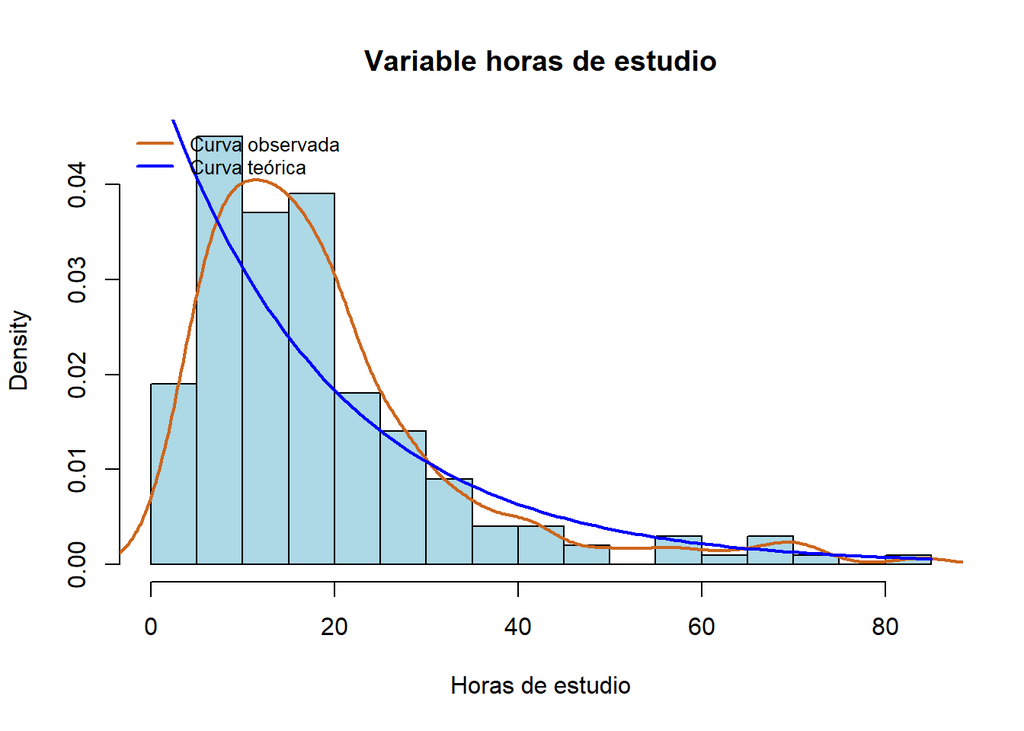

Como se puede observar en el histograma, la variable horas de estudio se asemeja a una variable aleatoria continua exponencial. Por lo que, a continuación se hallará el parámetro lambda a partir de su esperanza

Entonces, el valor del parámetro λ poblacional para esta variable es 0.05 aproximadamente.

- X ~ Exp(0.05)

## Análisis probabilístco

Las variable que forma parte de nuestro estudio, procedemos a sacar eventos con un enfoque en base a nuestros objetivos de la investigación, para posteriormente hallar sus probabilidades de ocurrencia.

### Eventos

De una muestra de 200 estudiantes en UTEC de los cuales 166 realizan actividad física y 34 no lo hacen ¿Cual es la probabilidad de que encontremos estudiantes con un peso no ideal? x2: variable aleatoria peso de los estudiantes en UTEC. Peso ~ Nor(68.69, 12.07) P(X2>80)

```r
z<-pnorm(80,mean=68.69,sd=12.07, lower.tail=F)
z
```

```
## [1] 0.1743705
```

La probabilidad de obtener pesos mayores a 80kg es del 17%, si la altura promedio de nuestra muestra es de 1.70, un peso ideal seria entre 55 y 68 kg, más de 80kg no seria un peso ideal.Es poco probable que en nuestra muestra encontremos estudiantes con un peso no ideal, ya que poseemos una muestra con un 83% que realiza actividad física.

## Probabilidades calculadas

```
## [1] 0.83
```

```
## [1] 0.17
```

### Eventos

X: Estudiantes de EL-MT Y: Numero de estudiantes que realizan más de 6 horas a la semana y que su promedio es mayor a 16

```r
phyper(4,36,200-36,40)
```

```
## [1] 0.1032256
```

## Correcciones

1- Se implemento más descriptores numéricos con sus respectivos valores, para concluir mejor nuestros análisis en la investigación.

2- Se empleo más gráficos, como los mosaicos, dispersiones, con un análisis correspondiente, para obtener más conclusiones con respecto a nuestro estudio.

3-Logramos juntar los descriptores analizados en nuestras interpretaciones, uniformizando y cumpliendo con una mejor presentación.

## Bibliografía

- Brígida Molina (Mayo 2022) . Variables Aleatorias Discretas . Recuperado de : file:///C:/Users/paola/Desktop/VAD-1%20(1).html#(1)
- Organización Mundial de la Salud (9 de junio de 2021). Obesidad y sobrepeso. Recuperado de : https://www.who.int/es/news-room/fact-sheets/detail/obesity-and-overweight
- https://www.youtube.com/watch?v=y5G88YmrZpA